# Model diagnostics for Stem 16S 3-level occupancy model.

## Load the model and packages

```
This is posterior version 1.5.0
```

[output not shown]

## MCMC diagnostics

Basic MCMC diagnostic checks. Models with divergent transitions, or large numbers of max_treedepth errors, are likely problematic and need refinement.

```
$num_divergent
[1] 0 0 0 0

$num_max_treedepth
[1] 0 0 0 0

$ebfmi
[1] 0.8931083 0.7387360 0.8032523 0.7159726
```

### Rhats

Rhat is a parameter-level summary statistic that attempts to summarise the convergence of a set of HMC/MCMC chains. A value close to 1 (approximately < 1.05) indicates chain convergence for that parameter. Below is a histogram of Rhat values for all model parameters, giving a rough at-a-glance summary of model convergence.

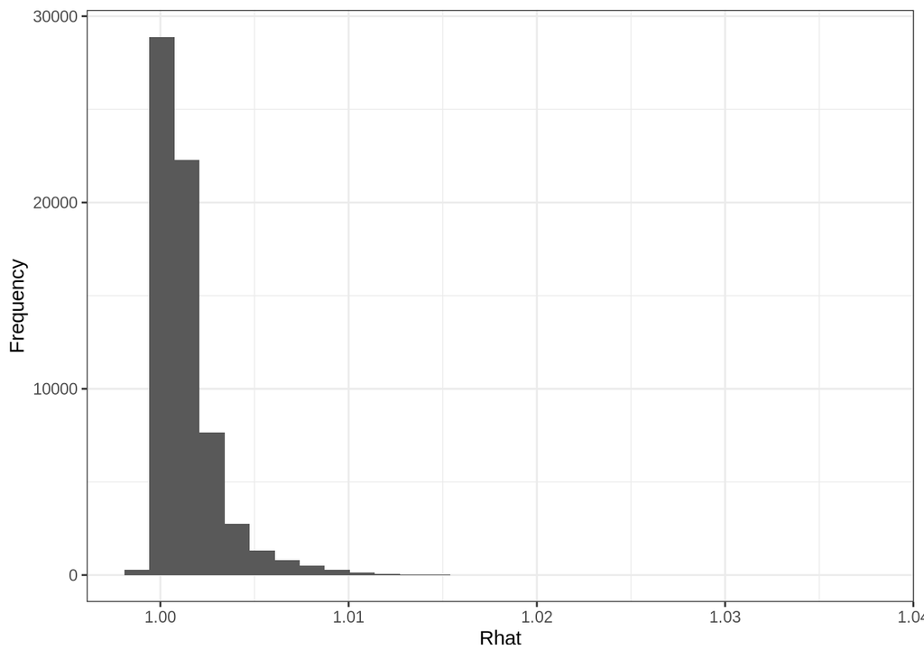

It should be noted that while this is a good rough guide, it is still important to inspect the MCMC chains more closely to gain further assurances of convergence.

### Trace plots

Below are MCMC traceplots for a selection of parameters of different types, to give a better overview of any convergence problems that may have occurred.

#### Sigmas

Site occupancy sigmas:

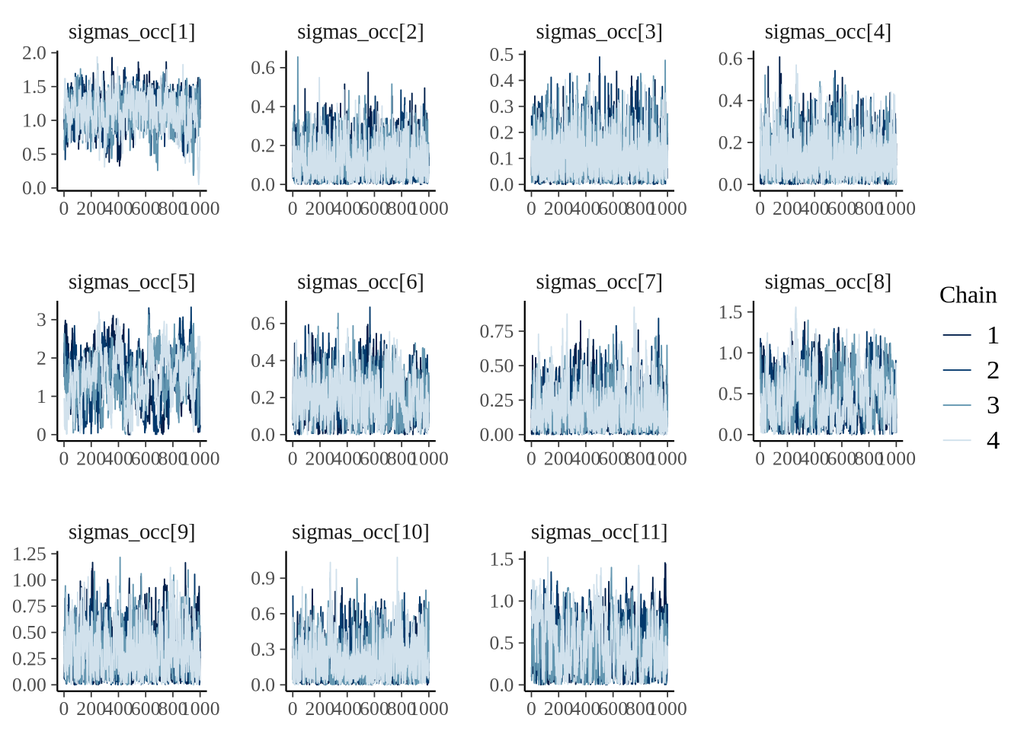

Sample occupancy sigmas:

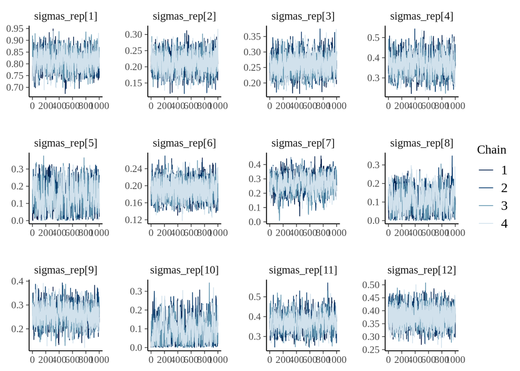

Detection sigmas:

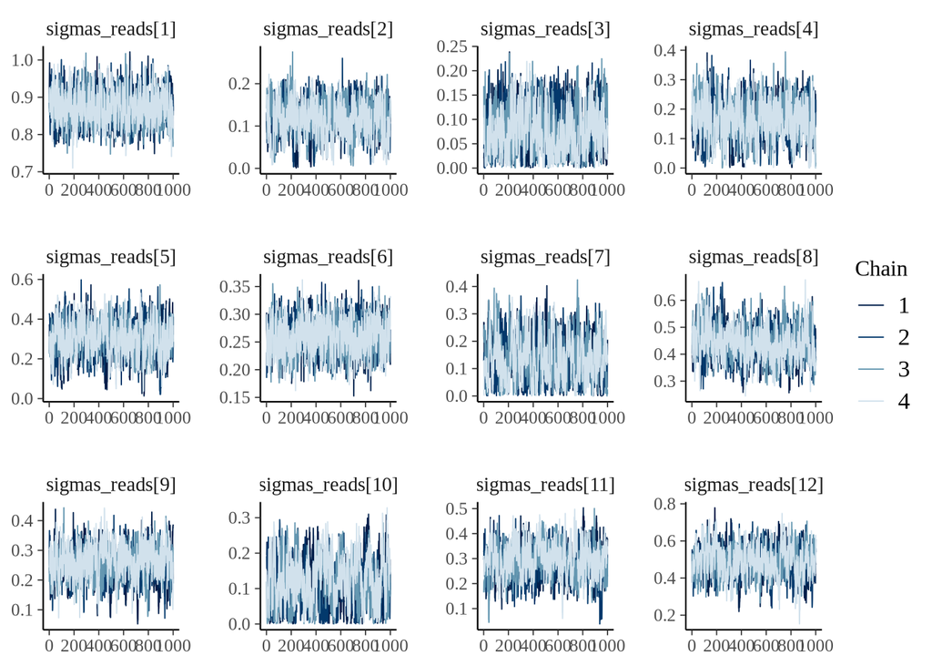

#### Fixed effects

Site occupancy:

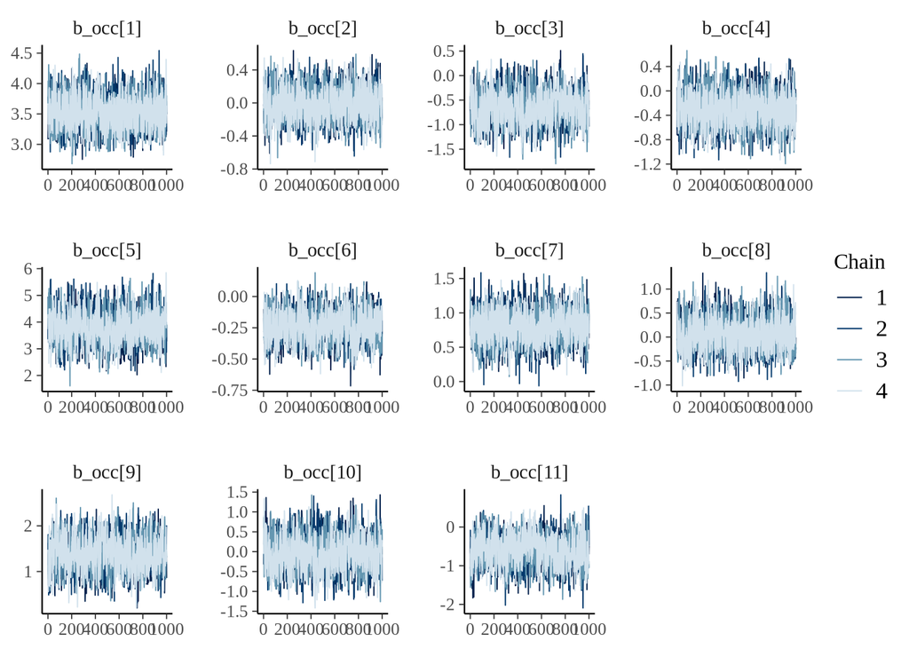

Sample occupancy:

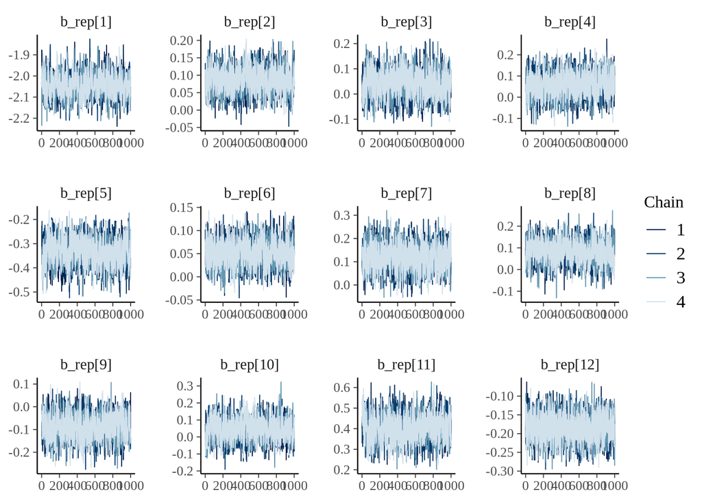

Detection:

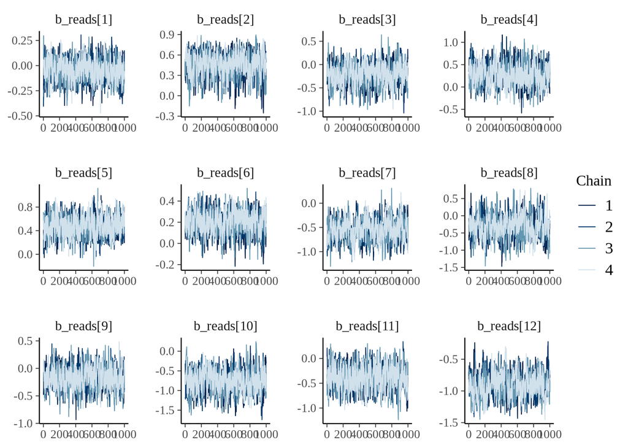

#### Species effects

Choose three random species to evaluate for:

```r
n_spp <- posterior::subset_draws(model_draws, "b_occ_species") |> as_draws_rvars() |> pluck("b_occ_species") |> ncol()
spp <- sample(n_spp, size = 3)

spp
```

```
[1] 580 257  59
```

Site occupancy:

[figure not shown]

Sample occupancy:

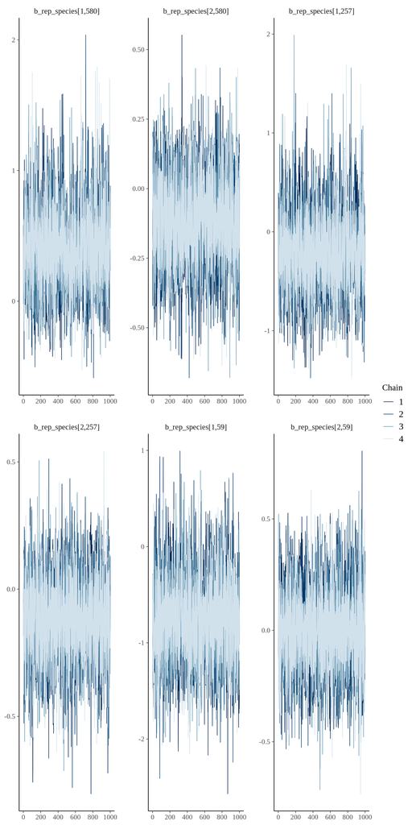

Detection:

[figure not shown]

#### Dispersion

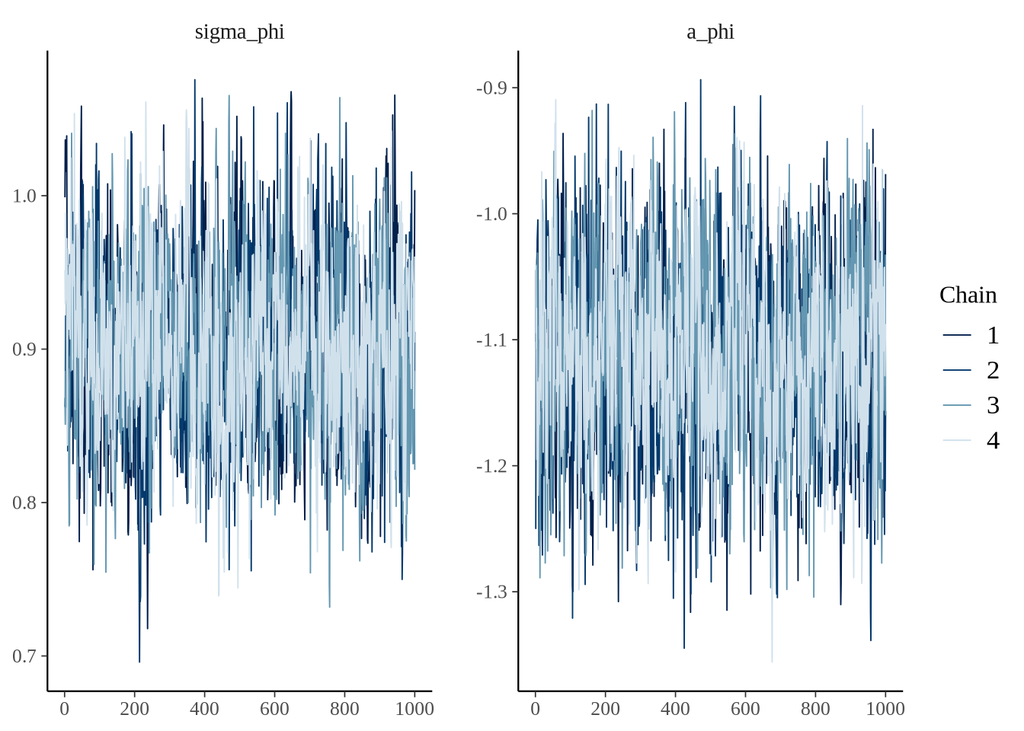

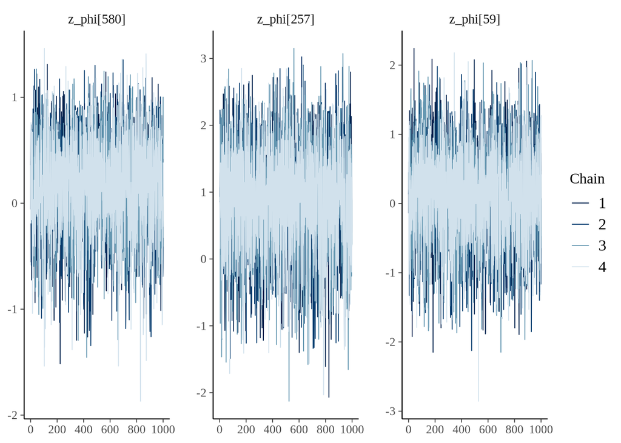

#### Size factors

```r
n_size_factors <-  posterior::subset_draws(model_draws, "SF") |> as_draws_rvars() |> pluck("SF") |> length()
sfs <- sample(n_size_factors, 10)

sfs
```

```
 [1]  70  27 293  91  78  76 255 298 107   1
```

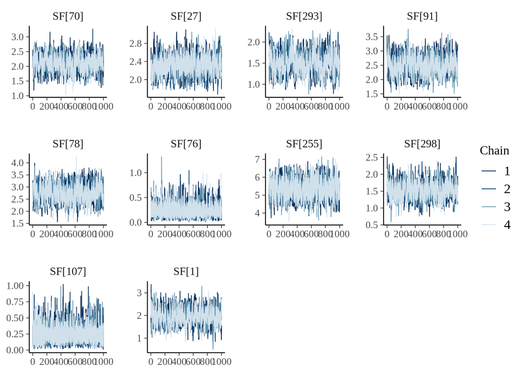

```r
posterior::subset_draws(model_draws, c("SF")) |> bayesplot::mcmc_trace(pars = vars(param_range("SF", sfs)))
```

## Leave-one-out cross-validation

Assuming MCMC diagnostics have passed, below is the leave-one-out cross validation score for the model, with moment matching.

```r
n_pars <- model_summary |>
  filter(!str_detect(variable, "species")) |>
  filter(variable != "phi") |>
  filter(variable != "log_lik")

n_pars
```

```
# A tibble: 43,059 × 10
   variable       mean   median      sd     mad       q5      q95  rhat ess_bulk
   <chr>         <dbl>    <dbl>   <dbl>   <dbl>    <dbl>    <dbl> <dbl>    <dbl>
 1 lp__       -1.24e+5 -1.24e+5 137.    136.    -1.25e+5 -1.24e+5  1.00     692.
 2 b_occ[1]    3.53e+0  3.52e+0   0.263   0.271  3.11e+0  3.97e+0  1.00    1258.
 3 b_occ[2]   -3.84e-3 -4.71e-3   0.192   0.199 -3.10e-1  3.09e-1  1.01     810.
 4 b_occ[3]   -6.34e-1 -6.37e-1   0.323   0.331 -1.15e+0 -9.94e-2  1.01     775.
 5 b_occ[4]   -2.93e-1 -2.92e-1   0.275   0.278 -7.52e-1  1.57e-1  1.01    1338.
 6 b_occ[5]    3.80e+0  3.79e+0   0.590   0.582  2.85e+0  4.81e+0  1.00     693.
 7 b_occ[6]   -2.34e-1 -2.34e-1   0.114   0.112 -4.29e-1 -4.78e-2  1.01    1304.
 8 b_occ[7]    8.02e-1  7.97e-1   0.228   0.228  4.29e-1  1.17e+0  1.01    1508.
 9 b_occ[8]    7.10e-2  5.87e-2   0.323   0.317 -4.46e-1  6.28e-1  1.00    1251.
10 b_occ[9]    1.37e+0  1.36e+0   0.360   0.365  7.97e-1  1.97e+0  1.01     822.
# ℹ 43,049 more rows
# ℹ 1 more variable: ess_tail <dbl>
```

```r
loo$estimates
```

```
          Estimate         SE
elpd_loo -94118.65 1186.58028
p_loo      4069.71   60.46272
looic    188237.29 2373.16055
```

## Goodness-of-fit

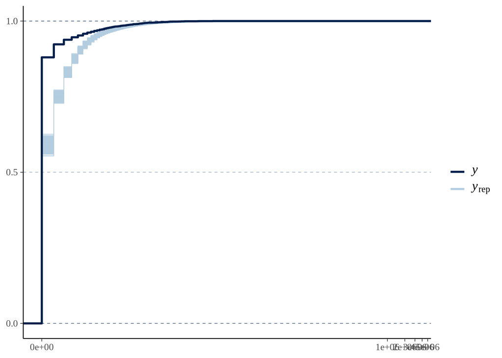

```r
Y <- model_data$Y |> {\(x) x[,,1]}() |> as.vector()
Y_rep <- model_postpreds$Y_rep |>
  t() |>
  as.vector()

len_Y <- length(Y)
max_sample <- 5000
if(len_Y > max_sample) {
  which_Y <- sample(1:len_Y, size = max_sample)
} else {
  which_Y <- 1:len_Y
}

bayesplot::ppc_ecdf_overlay(y = Y[which_Y],
                    yrep = draws_of(Y_rep[which_Y]),
                    discrete = TRUE
                    ) +
  scale_x_continuous(trans = "pseudo_log")
```

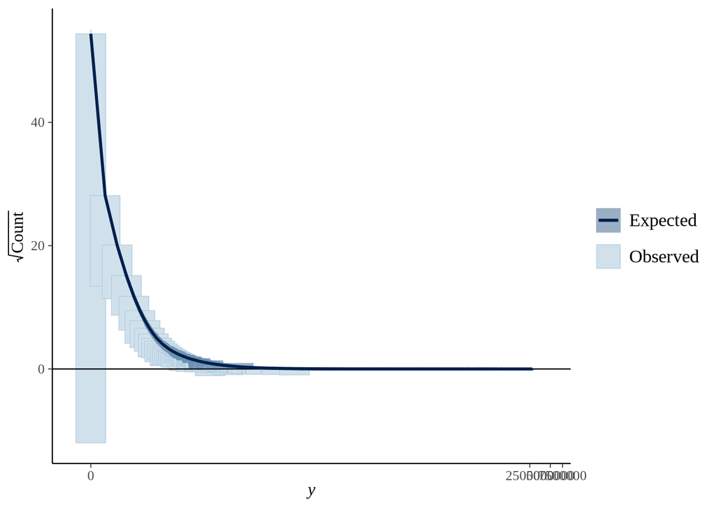

```r
bayesplot::ppc_rootogram(y = Y[which_Y],
                    yrep = draws_of(Y_rep[which_Y]),
                    style = "hanging"
                    ) +
  scale_x_continuous(trans = "pseudo_log")
```